# DRAFT — L3 Mature_B_core depth/PTPRC-matched spatial null

Six fixed L3 samples; descriptive spatial QC; pending manual review

**DRAFT — pending manual review**

This report is a descriptive spatial-QC analysis. It is not a disease comparison and does not call a B-cell niche, aggregate, TLS or hotspot. Rendering does not approve the interpretation.

## Executive summary

All six fixed L3 samples were retained without expression-based selection. `SSC/05957/17B` remains explicitly marked as an extremely low-capture sample. The analysis read the previously persisted `strict_same_bin` and `strict_rook` flags; it did not reconstruct a score, modify a marker or threshold, or inspect a new raw-count object.

For **IPF/FO23-1-06168**, the clustering-direction percentile was at least 100.0% for all four same-bin spatial metrics and 100.0% for all four rook metrics after exact depth/n_genes/PTPRC matching. Its same-bin largest component contained 10, 0.7567568, 28, 50 of 37, 37, 37, 37 supported Bins, versus a matched-null median of 35, 0.0540541, 2, 158.113883.

For **SSC/15491/14**, the corresponding minimum percentiles were 100.0% for same-bin and 100.0% for rook. Its same-bin largest component contained 36, 0.4461538, 29, 70.7106781 of 65, 65, 65, 65 supported Bins, versus a matched-null median of 62, 0.0307692, 2, 158.113883.

Thus matching the local sequencing-depth, gene-complexity and PTPRC background did **not** remove the focal clustering signal in either prespecified focus sample. Under the preregistered interpretation rule, both remain **depth-adjusted focal B-lineage candidates** for manual spatial review. This does not establish a B-cell niche, aggregate, TLS or disease difference.

The unmatched and matched nulls led to the same descriptive conclusion for both focus samples. Matching moved the null distributions toward greater clustering in several metrics, as expected, but the observed focus-sample values remained at or beyond the clustering-direction maximum of all 1,000 matched draws.

Important limitation: strict rook support is itself defined using rook adjacency. Its strong connectivity is therefore partly structural and must not be treated as independent biological evidence. The same-bin result is the less circular spatial diagnostic, and the six same-chip samples provide the relevant background context. Empirical percentiles in this report are descriptive ranks, not P values.

## Frozen scope and immutable inputs

Prespecified design and interpretation limits

| field | value |
| --- | --- |
| analysis_label | depth/PTPRC-matched spatial null analysis |
| status | DRAFT — pending manual review |
| immutable_bin_input | D:/bb/博士课题组资料/新建文件夹/自己课题相关/Lung ST/codex agent/stereo_seq/stereo_seq/results/reanalysis/bin50_l3_mature_b_focal_spatial_review_260823202319/tables/10_l3_bin_level_frozen_marker_and_support_values.tsv.… |
| immutable_input_md5 | 950a07b5982c359a7be43a822ec9bcfd |
| fixed_sample_n | 6 |
| fixed_samples | HC/NL-72; IPF/FO23-1-06168; IPF/FO23-1-06170; SSC/05957/17B; SSC/07998/15A; SSC/15491/14 |
| support_flags | read unchanged from persisted strict_same_bin and strict_rook columns |
| matching_depth | sample-specific empirical quintile of log1p(total_counts) |
| matching_complexity | sample-specific empirical quintile of n_genes |
| matching_immune_context | PTPRC raw-positive versus raw-zero |
| quintile_method | average rank; ties remain together; nominal empty cells allowed |
| matched_sampling | without replacement within every observed stratum; exact observed stratum counts |
| unmatched_sampling | uniform without replacement from all tissue Bins; same total support count |
| random_draw_n | 1000 |
| random_seed | 260824 |
| rook_definition | native x/y offset 50, same topology component |
| nearest_neighbor_definition | Euclidean distance in native coordinates among selected Bins, irrespective of component |
| inference_scope | descriptive spatial QC only; empirical percentiles are not P values |
| forbidden_interpretations | B-cell niche; aggregate; TLS; established disease difference |
| forbidden_analyses | disease testing; threshold optimization; Moran's I; hotspot scan; new marker selection |

Immutable source-file audit

| input_file | md5 | size_bytes | exists |
| --- | --- | --- | --- |
| D:/bb/博士课题组资料/新建文件夹/自己课题相关/Lung ST/codex agent/stereo_seq/stereo_seq/results/reanalysis/bin50_l3_mature_b_focal_spatial_review_260823202319/tables/10_l3_bin_level_frozen_marker_and_support_values.tsv.… | 950a07b5982c359a7be43a822ec9bcfd | 533295 | TRUE |
| D:/bb/博士课题组资料/新建文件夹/自己课题相关/Lung ST/codex agent/stereo_seq/stereo_seq/results/reanalysis/bin50_l3_mature_b_focal_spatial_review_260823202319/tables/01_fixed_l3_sample_manifest.tsv | 995197b6728d3021ad515347d99e689f | 841 | TRUE |
| D:/bb/博士课题组资料/新建文件夹/自己课题相关/Lung ST/codex agent/stereo_seq/stereo_seq/results/reanalysis/bin50_l3_mature_b_focal_spatial_review_260823202319/tables/05_mature_b_strict_support_summary.tsv | af5379370d9ff44b83e4d78c91c2c402 | 607 | TRUE |
| D:/bb/博士课题组资料/新建文件夹/自己课题相关/Lung ST/codex agent/stereo_seq/stereo_seq/results/reanalysis/bin50_l3_mature_b_focal_spatial_review_260823202319/tables/07_supported_bin_depth_overlap_vs_random.tsv | db6825258ae7c7c8a42cdf25ef71c4c1 | 3868 | TRUE |

All six fixed L3 samples

| sample_id | group | chip_id | total_bin_n | sample_total_counts | median_total_counts | median_n_genes | fixed_inclusion | candidate_detail_plot | capture_flag | selection_independent_of_b_expression |
| --- | --- | --- | --- | --- | --- | --- | --- | --- | --- | --- |
| HC/NL-72 | HC | Y40105L3 | 9919 | 3812324 | 303 | 242 | TRUE | FALSE | retained_L3_background_or_candidate | TRUE |
| IPF/FO23-1-06168 | IPF | Y40105L3 | 5358 | 1251687 | 146 | 119 | TRUE | TRUE | retained_L3_background_or_candidate | TRUE |
| IPF/FO23-1-06170 | IPF | Y40105L3 | 7156 | 1196230 | 147 | 122 | TRUE | FALSE | retained_L3_background_or_candidate | TRUE |
| SSC/05957/17B | SSc-ILD | Y40105L3 | 7325 | 523877 | 44 | 37 | TRUE | FALSE | prespecified_extremely_low_capture | TRUE |
| SSC/07998/15A | SSc-ILD | Y40105L3 | 6477 | 1782165 | 184 | 146 | TRUE | FALSE | retained_L3_background_or_candidate | TRUE |
| SSC/15491/14 | SSc-ILD | Y40105L3 | 10213 | 3551953 | 186 | 148 | TRUE | TRUE | retained_L3_background_or_candidate | TRUE |

The fixed matching layer for each tissue Bin was the cross-classification of sample-specific empirical quintiles of `log1p(total_counts)`, empirical quintiles of `n_genes`, and PTPRC raw-positive versus raw-zero status. Average ranks kept ties together. Each matched draw sampled without replacement and reproduced the observed stratum counts exactly.

## Frozen support validation

Persisted support flags versus frozen aggregate results

| sample_id | total_bin_n | strict_same_bin_supported_bin_n | strict_rook_supported_bin_n | frozen_total_bin_n | frozen_same_n | frozen_rook_n | total_n_exact | same_n_exact | rook_n_exact |
| --- | --- | --- | --- | --- | --- | --- | --- | --- | --- |
| HC/NL-72 | 9919 | 34 | 162 | 9919 | 34 | 162 | TRUE | TRUE | TRUE |
| IPF/FO23-1-06168 | 5358 | 37 | 129 | 5358 | 37 | 129 | TRUE | TRUE | TRUE |
| IPF/FO23-1-06170 | 7156 | 8 | 43 | 7156 | 8 | 43 | TRUE | TRUE | TRUE |
| SSC/05957/17B | 7325 | 0 | 4 | 7325 | 0 | 4 | TRUE | TRUE | TRUE |
| SSC/07998/15A | 6477 | 12 | 61 | 6477 | 12 | 61 | TRUE | TRUE | TRUE |
| SSC/15491/14 | 10213 | 65 | 243 | 10213 | 65 | 243 | TRUE | TRUE | TRUE |

Exact matching validation for all 12 sample/support-mode combinations

| sample_id | support_mode | supported_bin_n | random_draw_n | exact_stratum_composition_draw_n | all_draws_exact |
| --- | --- | --- | --- | --- | --- |
| HC/NL-72 | same_bin | 34 | 1000 | 1000 | TRUE |
| HC/NL-72 | rook | 162 | 1000 | 1000 | TRUE |
| IPF/FO23-1-06168 | same_bin | 37 | 1000 | 1000 | TRUE |
| IPF/FO23-1-06168 | rook | 129 | 1000 | 1000 | TRUE |
| IPF/FO23-1-06170 | same_bin | 8 | 1000 | 1000 | TRUE |
| IPF/FO23-1-06170 | rook | 43 | 1000 | 1000 | TRUE |
| SSC/05957/17B | same_bin | 0 | 1000 | 1000 | TRUE |
| SSC/05957/17B | rook | 4 | 1000 | 1000 | TRUE |
| SSC/07998/15A | same_bin | 12 | 1000 | 1000 | TRUE |
| SSC/07998/15A | rook | 61 | 1000 | 1000 | TRUE |
| SSC/15491/14 | same_bin | 65 | 1000 | 1000 | TRUE |
| SSC/15491/14 | rook | 243 | 1000 | 1000 | TRUE |

All 12000 matched random sets passed exact stratum-composition validation. Same-bin and rook were randomized independently.

## Spatial null results across all six samples

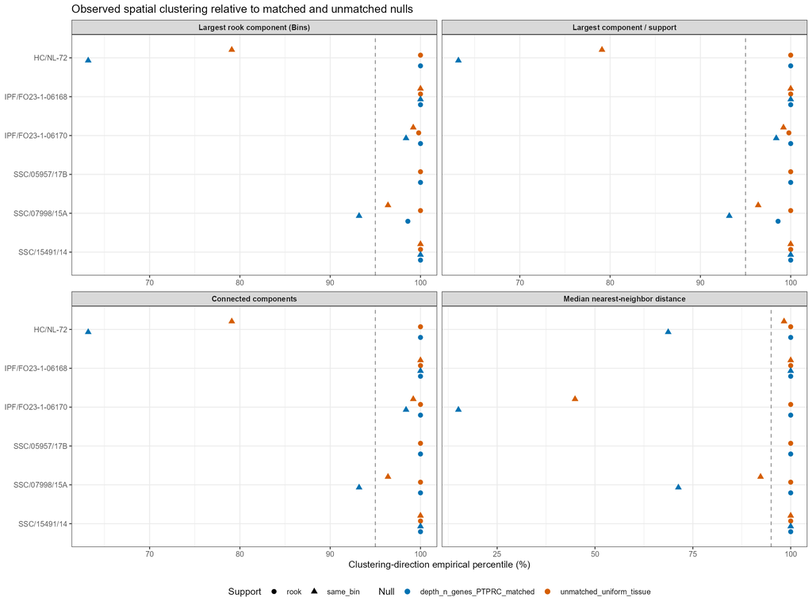

For largest-component size and fraction, larger values indicate stronger clustering. For component number and median nearest-neighbor distance, smaller values indicate stronger clustering. The “clustering-direction percentile” reverses the latter two so that higher always means more clustered than the null.

Observed values and 1,000-draw null summaries

| sample_id | group | chip_id | support_mode | supported_bin_n | null_type | metric | metric_label | observed_value | null_draw_n | null_min | null_q1 | null_median | null_q3 | null_max | empirical_cdf_percentile | clustering_direction_percentile |
| --- | --- | --- | --- | --- | --- | --- | --- | --- | --- | --- | --- | --- | --- | --- | --- | --- |
| HC/NL-72 | HC | Y40105L3 | rook | 162 | depth_n_genes_PTPRC_matched | connected_component_n | Connected components | 66.000 | 1000 | 143.000 | 151.000 | 153.000 | 155.000 | 161.000 | 0.0 | 100.0 |
| HC/NL-72 | HC | Y40105L3 | rook | 162 | depth_n_genes_PTPRC_matched | max_component_support_fraction | Largest component / support | 0.056 | 1000 | 0.012 | 0.012 | 0.019 | 0.019 | 0.037 | 100.0 | 100.0 |
| HC/NL-72 | HC | Y40105L3 | rook | 162 | depth_n_genes_PTPRC_matched | max_rook_component_bin_n | Largest rook component (Bins) | 9.000 | 1000 | 2.000 | 2.000 | 3.000 | 3.000 | 6.000 | 100.0 | 100.0 |
| HC/NL-72 | HC | Y40105L3 | rook | 162 | depth_n_genes_PTPRC_matched | median_nearest_neighbor_distance | Median nearest-neighbor distance | 50.000 | 1000 | 111.803 | 145.711 | 150.000 | 158.114 | 180.278 | 0.0 | 100.0 |
| HC/NL-72 | HC | Y40105L3 | rook | 162 | unmatched_uniform_tissue | connected_component_n | Connected components | 66.000 | 1000 | 149.000 | 155.000 | 157.000 | 158.000 | 162.000 | 0.0 | 100.0 |
| HC/NL-72 | HC | Y40105L3 | rook | 162 | unmatched_uniform_tissue | max_component_support_fraction | Largest component / support | 0.056 | 1000 | 0.006 | 0.012 | 0.012 | 0.012 | 0.031 | 100.0 | 100.0 |
| HC/NL-72 | HC | Y40105L3 | rook | 162 | unmatched_uniform_tissue | max_rook_component_bin_n | Largest rook component (Bins) | 9.000 | 1000 | 1.000 | 2.000 | 2.000 | 2.000 | 5.000 | 100.0 | 100.0 |
| HC/NL-72 | HC | Y40105L3 | rook | 162 | unmatched_uniform_tissue | median_nearest_neighbor_distance | Median nearest-neighbor distance | 50.000 | 1000 | 150.000 | 180.278 | 200.000 | 206.155 | 236.803 | 0.0 | 100.0 |
| HC/NL-72 | HC | Y40105L3 | same_bin | 34 | depth_n_genes_PTPRC_matched | connected_component_n | Connected components | 34.000 | 1000 | 31.000 | 33.000 | 34.000 | 34.000 | 34.000 | 100.0 | 63.2 |
| HC/NL-72 | HC | Y40105L3 | same_bin | 34 | depth_n_genes_PTPRC_matched | max_component_support_fraction | Largest component / support | 0.029 | 1000 | 0.029 | 0.029 | 0.029 | 0.059 | 0.088 | 63.2 | 63.2 |
| HC/NL-72 | HC | Y40105L3 | same_bin | 34 | depth_n_genes_PTPRC_matched | max_rook_component_bin_n | Largest rook component (Bins) | 1.000 | 1000 | 1.000 | 1.000 | 1.000 | 2.000 | 3.000 | 63.2 | 63.2 |
| HC/NL-72 | HC | Y40105L3 | same_bin | 34 | depth_n_genes_PTPRC_matched | median_nearest_neighbor_distance | Median nearest-neighbor distance | 292.743 | 1000 | 180.278 | 283.046 | 318.192 | 353.553 | 509.902 | 31.5 | 68.7 |
| HC/NL-72 | HC | Y40105L3 | same_bin | 34 | unmatched_uniform_tissue | connected_component_n | Connected components | 34.000 | 1000 | 31.000 | 34.000 | 34.000 | 34.000 | 34.000 | 100.0 | 79.1 |
| HC/NL-72 | HC | Y40105L3 | same_bin | 34 | unmatched_uniform_tissue | max_component_support_fraction | Largest component / support | 0.029 | 1000 | 0.029 | 0.029 | 0.029 | 0.029 | 0.059 | 79.1 | 79.1 |
| HC/NL-72 | HC | Y40105L3 | same_bin | 34 | unmatched_uniform_tissue | max_rook_component_bin_n | Largest rook component (Bins) | 1.000 | 1000 | 1.000 | 1.000 | 1.000 | 1.000 | 2.000 | 79.1 | 79.1 |
| HC/NL-72 | HC | Y40105L3 | same_bin | 34 | unmatched_uniform_tissue | median_nearest_neighbor_distance | Median nearest-neighbor distance | 292.743 | 1000 | 234.629 | 381.961 | 427.200 | 471.699 | 636.384 | 1.7 | 98.3 |
| IPF/FO23-1-06168 | IPF | Y40105L3 | rook | 129 | depth_n_genes_PTPRC_matched | connected_component_n | Connected components | 33.000 | 1000 | 97.000 | 107.000 | 110.000 | 113.000 | 123.000 | 0.0 | 100.0 |
| IPF/FO23-1-06168 | IPF | Y40105L3 | rook | 129 | depth_n_genes_PTPRC_matched | max_component_support_fraction | Largest component / support | 0.450 | 1000 | 0.016 | 0.031 | 0.031 | 0.047 | 0.101 | 100.0 | 100.0 |
| IPF/FO23-1-06168 | IPF | Y40105L3 | rook | 129 | depth_n_genes_PTPRC_matched | max_rook_component_bin_n | Largest rook component (Bins) | 58.000 | 1000 | 2.000 | 4.000 | 4.000 | 6.000 | 13.000 | 100.0 | 100.0 |
| IPF/FO23-1-06168 | IPF | Y40105L3 | rook | 129 | depth_n_genes_PTPRC_matched | median_nearest_neighbor_distance | Median nearest-neighbor distance | 50.000 | 1000 | 70.711 | 100.000 | 100.000 | 111.803 | 141.421 | 0.0 | 100.0 |
| IPF/FO23-1-06168 | IPF | Y40105L3 | rook | 129 | unmatched_uniform_tissue | connected_component_n | Connected components | 33.000 | 1000 | 115.000 | 122.000 | 123.000 | 125.000 | 129.000 | 0.0 | 100.0 |
| IPF/FO23-1-06168 | IPF | Y40105L3 | rook | 129 | unmatched_uniform_tissue | max_component_support_fraction | Largest component / support | 0.450 | 1000 | 0.008 | 0.016 | 0.016 | 0.023 | 0.039 | 100.0 | 100.0 |
| IPF/FO23-1-06168 | IPF | Y40105L3 | rook | 129 | unmatched_uniform_tissue | max_rook_component_bin_n | Largest rook component (Bins) | 58.000 | 1000 | 1.000 | 2.000 | 2.000 | 3.000 | 5.000 | 100.0 | 100.0 |
| IPF/FO23-1-06168 | IPF | Y40105L3 | rook | 129 | unmatched_uniform_tissue | median_nearest_neighbor_distance | Median nearest-neighbor distance | 50.000 | 1000 | 111.803 | 150.000 | 158.114 | 158.114 | 206.155 | 0.0 | 100.0 |
| IPF/FO23-1-06168 | IPF | Y40105L3 | same_bin | 37 | depth_n_genes_PTPRC_matched | connected_component_n | Connected components | 10.000 | 1000 | 28.000 | 34.000 | 35.000 | 36.000 | 37.000 | 0.0 | 100.0 |
| IPF/FO23-1-06168 | IPF | Y40105L3 | same_bin | 37 | depth_n_genes_PTPRC_matched | max_component_support_fraction | Largest component / support | 0.757 | 1000 | 0.027 | 0.054 | 0.054 | 0.054 | 0.189 | 100.0 | 100.0 |
| IPF/FO23-1-06168 | IPF | Y40105L3 | same_bin | 37 | depth_n_genes_PTPRC_matched | max_rook_component_bin_n | Largest rook component (Bins) | 28.000 | 1000 | 1.000 | 2.000 | 2.000 | 2.000 | 7.000 | 100.0 | 100.0 |
| IPF/FO23-1-06168 | IPF | Y40105L3 | same_bin | 37 | depth_n_genes_PTPRC_matched | median_nearest_neighbor_distance | Median nearest-neighbor distance | 50.000 | 1000 | 100.000 | 150.000 | 158.114 | 200.000 | 269.258 | 0.0 | 100.0 |
| IPF/FO23-1-06168 | IPF | Y40105L3 | same_bin | 37 | unmatched_uniform_tissue | connected_component_n | Connected components | 10.000 | 1000 | 33.000 | 36.000 | 37.000 | 37.000 | 37.000 | 0.0 | 100.0 |
| IPF/FO23-1-06168 | IPF | Y40105L3 | same_bin | 37 | unmatched_uniform_tissue | max_component_support_fraction | Largest component / support | 0.757 | 1000 | 0.027 | 0.027 | 0.027 | 0.054 | 0.081 | 100.0 | 100.0 |

[output cut: 66 more lines]

`SSC/05957/17B` had zero same-bin supported Bins. Its observed zeros are retained, but spatial percentiles are reported as not estimable rather than treating an empty set as clustered.

## Focused review: IPF/FO23-1-06168 and SSC/15491/14

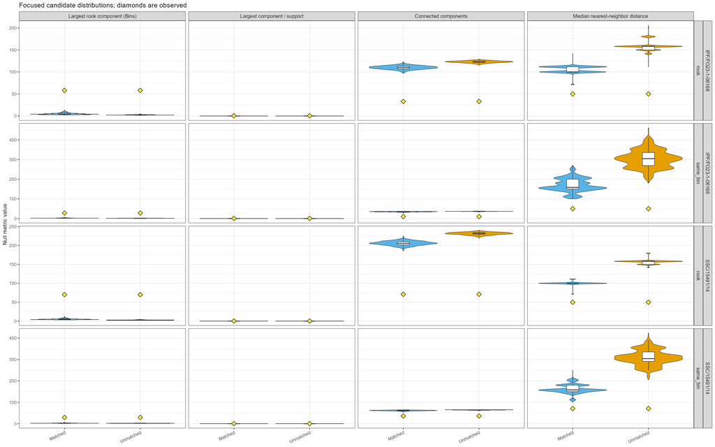

Prespecified focus-sample spatial metrics

| sample_id | group | chip_id | support_mode | supported_bin_n | metric | metric_label | observed_value | null_median_depth_n_genes_PTPRC_matched | null_median_unmatched_uniform_tissue | clustering_direction_percentile_depth_n_genes_PTPRC_matched | clustering_direction_percentile_unmatched_uniform_tissue | percentile_change_matched_minus_unmatched | matched_null_interpretation |
| --- | --- | --- | --- | --- | --- | --- | --- | --- | --- | --- | --- | --- | --- |
| IPF/FO23-1-06168 | IPF | Y40105L3 | rook | 129 | connected_component_n | Connected components | 33.000 | 110.000 | 123.000 | 100 | 100 | 0 | observed clustering is at or beyond the clustering-direction maximum of all 1000 matched draws |
| IPF/FO23-1-06168 | IPF | Y40105L3 | rook | 129 | max_component_support_fraction | Largest component / support | 0.450 | 0.031 | 0.016 | 100 | 100 | 0 | observed clustering is at or beyond the clustering-direction maximum of all 1000 matched draws |
| IPF/FO23-1-06168 | IPF | Y40105L3 | rook | 129 | max_rook_component_bin_n | Largest rook component (Bins) | 58.000 | 4.000 | 2.000 | 100 | 100 | 0 | observed clustering is at or beyond the clustering-direction maximum of all 1000 matched draws |
| IPF/FO23-1-06168 | IPF | Y40105L3 | rook | 129 | median_nearest_neighbor_distance | Median nearest-neighbor distance | 50.000 | 100.000 | 158.114 | 100 | 100 | 0 | observed clustering is at or beyond the clustering-direction maximum of all 1000 matched draws |
| IPF/FO23-1-06168 | IPF | Y40105L3 | same_bin | 37 | connected_component_n | Connected components | 10.000 | 35.000 | 37.000 | 100 | 100 | 0 | observed clustering is at or beyond the clustering-direction maximum of all 1000 matched draws |
| IPF/FO23-1-06168 | IPF | Y40105L3 | same_bin | 37 | max_component_support_fraction | Largest component / support | 0.757 | 0.054 | 0.027 | 100 | 100 | 0 | observed clustering is at or beyond the clustering-direction maximum of all 1000 matched draws |
| IPF/FO23-1-06168 | IPF | Y40105L3 | same_bin | 37 | max_rook_component_bin_n | Largest rook component (Bins) | 28.000 | 2.000 | 1.000 | 100 | 100 | 0 | observed clustering is at or beyond the clustering-direction maximum of all 1000 matched draws |
| IPF/FO23-1-06168 | IPF | Y40105L3 | same_bin | 37 | median_nearest_neighbor_distance | Median nearest-neighbor distance | 50.000 | 158.114 | 304.138 | 100 | 100 | 0 | observed clustering is at or beyond the clustering-direction maximum of all 1000 matched draws |
| SSC/15491/14 | SSc-ILD | Y40105L3 | rook | 243 | connected_component_n | Connected components | 71.000 | 206.000 | 232.000 | 100 | 100 | 0 | observed clustering is at or beyond the clustering-direction maximum of all 1000 matched draws |
| SSC/15491/14 | SSc-ILD | Y40105L3 | rook | 243 | max_component_support_fraction | Largest component / support | 0.288 | 0.021 | 0.012 | 100 | 100 | 0 | observed clustering is at or beyond the clustering-direction maximum of all 1000 matched draws |
| SSC/15491/14 | SSc-ILD | Y40105L3 | rook | 243 | max_rook_component_bin_n | Largest rook component (Bins) | 70.000 | 5.000 | 3.000 | 100 | 100 | 0 | observed clustering is at or beyond the clustering-direction maximum of all 1000 matched draws |
| SSC/15491/14 | SSc-ILD | Y40105L3 | rook | 243 | median_nearest_neighbor_distance | Median nearest-neighbor distance | 50.000 | 100.000 | 158.114 | 100 | 100 | 0 | observed clustering is at or beyond the clustering-direction maximum of all 1000 matched draws |
| SSC/15491/14 | SSc-ILD | Y40105L3 | same_bin | 65 | connected_component_n | Connected components | 36.000 | 62.000 | 64.000 | 100 | 100 | 0 | observed clustering is at or beyond the clustering-direction maximum of all 1000 matched draws |
| SSC/15491/14 | SSc-ILD | Y40105L3 | same_bin | 65 | max_component_support_fraction | Largest component / support | 0.446 | 0.031 | 0.031 | 100 | 100 | 0 | observed clustering is at or beyond the clustering-direction maximum of all 1000 matched draws |
| SSC/15491/14 | SSc-ILD | Y40105L3 | same_bin | 65 | max_rook_component_bin_n | Largest rook component (Bins) | 29.000 | 2.000 | 2.000 | 100 | 100 | 0 | observed clustering is at or beyond the clustering-direction maximum of all 1000 matched draws |
| SSC/15491/14 | SSc-ILD | Y40105L3 | same_bin | 65 | median_nearest_neighbor_distance | Median nearest-neighbor distance | 70.711 | 158.114 | 304.138 | 100 | 100 | 0 | observed clustering is at or beyond the clustering-direction maximum of all 1000 matched draws |

The yellow diamonds are observed values. The matched distribution preserves support-set size and the exact joint depth/n_genes/PTPRC stratum counts. The unmatched distribution preserves only support-set size.

## Did matching change the conclusion?

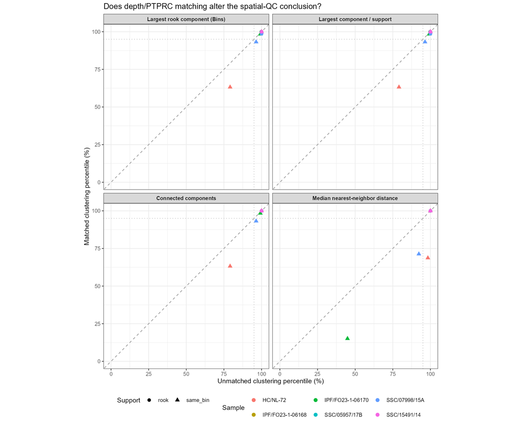

Metric-wise unmatched versus matched comparison

| sample_id | group | chip_id | support_mode | supported_bin_n | metric | metric_label | observed_value | null_median_depth_n_genes_PTPRC_matched | null_median_unmatched_uniform_tissue | clustering_direction_percentile_depth_n_genes_PTPRC_matched | clustering_direction_percentile_unmatched_uniform_tissue | percentile_change_matched_minus_unmatched |
| --- | --- | --- | --- | --- | --- | --- | --- | --- | --- | --- | --- | --- |
| HC/NL-72 | HC | Y40105L3 | rook | 162 | connected_component_n | Connected components | 66.000 | 153.000 | 157.000 | 100.0 | 100.0 | 0.0 |
| HC/NL-72 | HC | Y40105L3 | rook | 162 | max_component_support_fraction | Largest component / support | 0.056 | 0.019 | 0.012 | 100.0 | 100.0 | 0.0 |
| HC/NL-72 | HC | Y40105L3 | rook | 162 | max_rook_component_bin_n | Largest rook component (Bins) | 9.000 | 3.000 | 2.000 | 100.0 | 100.0 | 0.0 |
| HC/NL-72 | HC | Y40105L3 | rook | 162 | median_nearest_neighbor_distance | Median nearest-neighbor distance | 50.000 | 150.000 | 200.000 | 100.0 | 100.0 | 0.0 |
| HC/NL-72 | HC | Y40105L3 | same_bin | 34 | connected_component_n | Connected components | 34.000 | 34.000 | 34.000 | 63.2 | 79.1 | -15.9 |
| HC/NL-72 | HC | Y40105L3 | same_bin | 34 | max_component_support_fraction | Largest component / support | 0.029 | 0.029 | 0.029 | 63.2 | 79.1 | -15.9 |
| HC/NL-72 | HC | Y40105L3 | same_bin | 34 | max_rook_component_bin_n | Largest rook component (Bins) | 1.000 | 1.000 | 1.000 | 63.2 | 79.1 | -15.9 |
| HC/NL-72 | HC | Y40105L3 | same_bin | 34 | median_nearest_neighbor_distance | Median nearest-neighbor distance | 292.743 | 318.192 | 427.200 | 68.7 | 98.3 | -29.6 |
| IPF/FO23-1-06168 | IPF | Y40105L3 | rook | 129 | connected_component_n | Connected components | 33.000 | 110.000 | 123.000 | 100.0 | 100.0 | 0.0 |
| IPF/FO23-1-06168 | IPF | Y40105L3 | rook | 129 | max_component_support_fraction | Largest component / support | 0.450 | 0.031 | 0.016 | 100.0 | 100.0 | 0.0 |
| IPF/FO23-1-06168 | IPF | Y40105L3 | rook | 129 | max_rook_component_bin_n | Largest rook component (Bins) | 58.000 | 4.000 | 2.000 | 100.0 | 100.0 | 0.0 |
| IPF/FO23-1-06168 | IPF | Y40105L3 | rook | 129 | median_nearest_neighbor_distance | Median nearest-neighbor distance | 50.000 | 100.000 | 158.114 | 100.0 | 100.0 | 0.0 |
| IPF/FO23-1-06168 | IPF | Y40105L3 | same_bin | 37 | connected_component_n | Connected components | 10.000 | 35.000 | 37.000 | 100.0 | 100.0 | 0.0 |
| IPF/FO23-1-06168 | IPF | Y40105L3 | same_bin | 37 | max_component_support_fraction | Largest component / support | 0.757 | 0.054 | 0.027 | 100.0 | 100.0 | 0.0 |
| IPF/FO23-1-06168 | IPF | Y40105L3 | same_bin | 37 | max_rook_component_bin_n | Largest rook component (Bins) | 28.000 | 2.000 | 1.000 | 100.0 | 100.0 | 0.0 |
| IPF/FO23-1-06168 | IPF | Y40105L3 | same_bin | 37 | median_nearest_neighbor_distance | Median nearest-neighbor distance | 50.000 | 158.114 | 304.138 | 100.0 | 100.0 | 0.0 |
| IPF/FO23-1-06170 | IPF | Y40105L3 | rook | 43 | connected_component_n | Connected components | 21.000 | 42.500 | 43.000 | 100.0 | 100.0 | 0.0 |
| IPF/FO23-1-06170 | IPF | Y40105L3 | rook | 43 | max_component_support_fraction | Largest component / support | 0.070 | 0.035 | 0.023 | 100.0 | 99.8 | 0.2 |
| IPF/FO23-1-06170 | IPF | Y40105L3 | rook | 43 | max_rook_component_bin_n | Largest rook component (Bins) | 3.000 | 1.500 | 1.000 | 100.0 | 99.8 | 0.2 |
| IPF/FO23-1-06170 | IPF | Y40105L3 | rook | 43 | median_nearest_neighbor_distance | Median nearest-neighbor distance | 50.000 | 269.258 | 320.156 | 100.0 | 100.0 | 0.0 |
| IPF/FO23-1-06170 | IPF | Y40105L3 | same_bin | 8 | connected_component_n | Connected components | 8.000 | 8.000 | 8.000 | 98.4 | 99.2 | -0.8 |
| IPF/FO23-1-06170 | IPF | Y40105L3 | same_bin | 8 | max_component_support_fraction | Largest component / support | 0.125 | 0.125 | 0.125 | 98.4 | 99.2 | -0.8 |
| IPF/FO23-1-06170 | IPF | Y40105L3 | same_bin | 8 | max_rook_component_bin_n | Largest rook component (Bins) | 1.000 | 1.000 | 1.000 | 98.4 | 99.2 | -0.8 |
| IPF/FO23-1-06170 | IPF | Y40105L3 | same_bin | 8 | median_nearest_neighbor_distance | Median nearest-neighbor distance | 850.000 | 636.423 | 815.364 | 15.1 | 44.9 | -29.8 |
| SSC/05957/17B | SSc-ILD | Y40105L3 | rook | 4 | connected_component_n | Connected components | 2.000 | 4.000 | 4.000 | 100.0 | 100.0 | 0.0 |
| SSC/05957/17B | SSc-ILD | Y40105L3 | rook | 4 | max_component_support_fraction | Largest component / support | 0.500 | 0.250 | 0.250 | 100.0 | 100.0 | 0.0 |
| SSC/05957/17B | SSc-ILD | Y40105L3 | rook | 4 | max_rook_component_bin_n | Largest rook component (Bins) | 2.000 | 1.000 | 1.000 | 100.0 | 100.0 | 0.0 |
| SSC/05957/17B | SSc-ILD | Y40105L3 | rook | 4 | median_nearest_neighbor_distance | Median nearest-neighbor distance | 50.000 | 626.770 | 1233.551 | 100.0 | 100.0 | 0.0 |
| SSC/05957/17B | SSc-ILD | Y40105L3 | same_bin | 0 | connected_component_n | Connected components | 0.000 | 0.000 | 0.000 | NA | NA | NA |
| SSC/05957/17B | SSc-ILD | Y40105L3 | same_bin | 0 | max_component_support_fraction | Largest component / support | NA | NA | NA | NA | NA | NA |
| SSC/05957/17B | SSc-ILD | Y40105L3 | same_bin | 0 | max_rook_component_bin_n | Largest rook component (Bins) | 0.000 | 0.000 | 0.000 | NA | NA | NA |
| SSC/05957/17B | SSc-ILD | Y40105L3 | same_bin | 0 | median_nearest_neighbor_distance | Median nearest-neighbor distance | NA | NA | NA | NA | NA | NA |
| SSC/07998/15A | SSc-ILD | Y40105L3 | rook | 61 | connected_component_n | Connected components | 29.000 | 59.000 | 60.000 | 100.0 | 100.0 | 0.0 |
| SSC/07998/15A | SSc-ILD | Y40105L3 | rook | 61 | max_component_support_fraction | Largest component / support | 0.049 | 0.033 | 0.033 | 98.6 | 100.0 | -1.4 |
| SSC/07998/15A | SSc-ILD | Y40105L3 | rook | 61 | max_rook_component_bin_n | Largest rook component (Bins) | 3.000 | 2.000 | 2.000 | 98.6 | 100.0 | -1.4 |
| SSC/07998/15A | SSc-ILD | Y40105L3 | rook | 61 | median_nearest_neighbor_distance | Median nearest-neighbor distance | 50.000 | 180.278 | 254.951 | 100.0 | 100.0 | 0.0 |
| SSC/07998/15A | SSc-ILD | Y40105L3 | same_bin | 12 | connected_component_n | Connected components | 12.000 | 12.000 | 12.000 | 93.2 | 96.4 | -3.2 |
| SSC/07998/15A | SSc-ILD | Y40105L3 | same_bin | 12 | max_component_support_fraction | Largest component / support | 0.083 | 0.083 | 0.083 | 93.2 | 96.4 | -3.2 |
| SSC/07998/15A | SSc-ILD | Y40105L3 | same_bin | 12 | max_rook_component_bin_n | Largest rook component (Bins) | 1.000 | 1.000 | 1.000 | 93.2 | 96.4 | -3.2 |
| SSC/07998/15A | SSc-ILD | Y40105L3 | same_bin | 12 | median_nearest_neighbor_distance | Median nearest-neighbor distance | 425.832 | 500.000 | 628.032 | 71.3 | 92.3 | -21.0 |
| SSC/15491/14 | SSc-ILD | Y40105L3 | rook | 243 | connected_component_n | Connected components | 71.000 | 206.000 | 232.000 | 100.0 | 100.0 | 0.0 |
| SSC/15491/14 | SSc-ILD | Y40105L3 | rook | 243 | max_component_support_fraction | Largest component / support | 0.288 | 0.021 | 0.012 | 100.0 | 100.0 | 0.0 |
| SSC/15491/14 | SSc-ILD | Y40105L3 | rook | 243 | max_rook_component_bin_n | Largest rook component (Bins) | 70.000 | 5.000 | 3.000 | 100.0 | 100.0 | 0.0 |
| SSC/15491/14 | SSc-ILD | Y40105L3 | rook | 243 | median_nearest_neighbor_distance | Median nearest-neighbor distance | 50.000 | 100.000 | 158.114 | 100.0 | 100.0 | 0.0 |
| SSC/15491/14 | SSc-ILD | Y40105L3 | same_bin | 65 | connected_component_n | Connected components | 36.000 | 62.000 | 64.000 | 100.0 | 100.0 | 0.0 |
| SSC/15491/14 | SSc-ILD | Y40105L3 | same_bin | 65 | max_component_support_fraction | Largest component / support | 0.446 | 0.031 | 0.031 | 100.0 | 100.0 | 0.0 |
| SSC/15491/14 | SSc-ILD | Y40105L3 | same_bin | 65 | max_rook_component_bin_n | Largest rook component (Bins) | 29.000 | 2.000 | 2.000 | 100.0 | 100.0 | 0.0 |
| SSC/15491/14 | SSc-ILD | Y40105L3 | same_bin | 65 | median_nearest_neighbor_distance | Median nearest-neighbor distance | 70.711 | 158.114 | 304.138 | 100.0 | 100.0 | 0.0 |

The preceding L3 review used uniform same-count tissue-Bin draws to describe overlap with top-depth and top-n_genes regions. That original table is retained unchanged below. The newly generated unmatched spatial null uses the same uniform, without-replacement sampling concept but evaluates spatial metrics, allowing a like-for-like comparison with the matched spatial null.

Carried-forward prior unmatched depth-overlap result

| sample_id | support_mode | depth_metric | support_bin_n | tissue_bin_n | depth_p90_threshold | actual_top10_region_bin_n | actual_top10_region_fraction | observed_supported_bin_top10_overlap_n | observed_supported_bin_top10_overlap_fraction | random_median | random_q1 | random_q3 | observed_to_random_median_ratio | descriptive_only_no_inference |
| --- | --- | --- | --- | --- | --- | --- | --- | --- | --- | --- | --- | --- | --- | --- |
| HC/NL-72 | same_bin | total_counts | 34 | 9919 | 736.2 | 992 | 0.100 | 18 | 0.529 | 0.088 | 0.059 | 0.118 | 6.000 | TRUE |
| HC/NL-72 | same_bin | n_genes | 34 | 9919 | 565.2 | 992 | 0.100 | 18 | 0.529 | 0.088 | 0.059 | 0.118 | 6.000 | TRUE |
| HC/NL-72 | rook | total_counts | 162 | 9919 | 736.2 | 992 | 0.100 | 67 | 0.414 | 0.099 | 0.086 | 0.117 | 4.188 | TRUE |
| HC/NL-72 | rook | n_genes | 162 | 9919 | 565.2 | 992 | 0.100 | 66 | 0.407 | 0.099 | 0.086 | 0.117 | 4.125 | TRUE |
| IPF/FO23-1-06168 | same_bin | total_counts | 37 | 5358 | 490.0 | 539 | 0.101 | 33 | 0.892 | 0.108 | 0.054 | 0.135 | 8.250 | TRUE |
| IPF/FO23-1-06168 | same_bin | n_genes | 37 | 5358 | 388.3 | 536 | 0.100 | 33 | 0.892 | 0.108 | 0.054 | 0.135 | 8.250 | TRUE |
| IPF/FO23-1-06168 | rook | total_counts | 129 | 5358 | 490.0 | 539 | 0.101 | 90 | 0.698 | 0.101 | 0.085 | 0.116 | 6.923 | TRUE |
| IPF/FO23-1-06168 | rook | n_genes | 129 | 5358 | 388.3 | 536 | 0.100 | 90 | 0.698 | 0.101 | 0.078 | 0.116 | 6.923 | TRUE |
| IPF/FO23-1-06170 | same_bin | total_counts | 8 | 7156 | 336.5 | 716 | 0.100 | 1 | 0.125 | 0.125 | 0.000 | 0.125 | 1.000 | TRUE |
| IPF/FO23-1-06170 | same_bin | n_genes | 8 | 7156 | 272.0 | 726 | 0.101 | 1 | 0.125 | 0.125 | 0.000 | 0.125 | 1.000 | TRUE |
| IPF/FO23-1-06170 | rook | total_counts | 43 | 7156 | 336.5 | 716 | 0.100 | 4 | 0.093 | 0.093 | 0.070 | 0.140 | 1.000 | TRUE |
| IPF/FO23-1-06170 | rook | n_genes | 43 | 7156 | 272.0 | 726 | 0.101 | 4 | 0.093 | 0.093 | 0.070 | 0.140 | 1.000 | TRUE |
| SSC/05957/17B | same_bin | total_counts | 0 | 7325 | 174.0 | 743 | 0.101 | 0 | NA | NA | NA | NA | NA | TRUE |
| SSC/05957/17B | same_bin | n_genes | 0 | 7325 | 145.0 | 737 | 0.101 | 0 | NA | NA | NA | NA | NA | TRUE |
| SSC/05957/17B | rook | total_counts | 4 | 7325 | 174.0 | 743 | 0.101 | 4 | 1.000 | 0.000 | 0.000 | 0.250 | NA | TRUE |
| SSC/05957/17B | rook | n_genes | 4 | 7325 | 145.0 | 737 | 0.101 | 4 | 1.000 | 0.000 | 0.000 | 0.250 | NA | TRUE |
| SSC/07998/15A | same_bin | total_counts | 12 | 6477 | 599.4 | 648 | 0.100 | 2 | 0.167 | 0.083 | 0.000 | 0.167 | 2.000 | TRUE |
| SSC/07998/15A | same_bin | n_genes | 12 | 6477 | 469.4 | 648 | 0.100 | 3 | 0.250 | 0.083 | 0.000 | 0.167 | 3.000 | TRUE |
| SSC/07998/15A | rook | total_counts | 61 | 6477 | 599.4 | 648 | 0.100 | 27 | 0.443 | 0.098 | 0.082 | 0.131 | 4.500 | TRUE |
| SSC/07998/15A | rook | n_genes | 61 | 6477 | 469.4 | 648 | 0.100 | 25 | 0.410 | 0.098 | 0.082 | 0.131 | 4.167 | TRUE |
| SSC/15491/14 | same_bin | total_counts | 65 | 10213 | 701.0 | 1025 | 0.100 | 54 | 0.831 | 0.092 | 0.077 | 0.123 | 9.000 | TRUE |
| SSC/15491/14 | same_bin | n_genes | 65 | 10213 | 537.0 | 1023 | 0.100 | 53 | 0.815 | 0.092 | 0.077 | 0.123 | 8.833 | TRUE |
| SSC/15491/14 | rook | total_counts | 243 | 10213 | 701.0 | 1025 | 0.100 | 161 | 0.663 | 0.099 | 0.086 | 0.115 | 6.708 | TRUE |
| SSC/15491/14 | rook | n_genes | 243 | 10213 | 537.0 | 1023 | 0.100 | 162 | 0.667 | 0.099 | 0.086 | 0.111 | 6.750 | TRUE |

## Matching composition audit

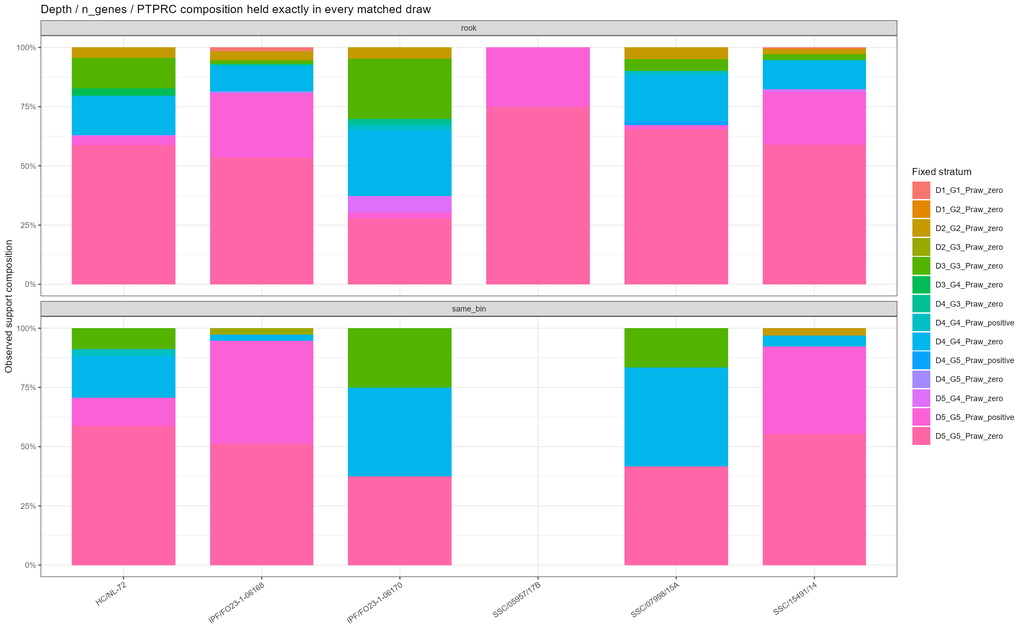

Fixed matching strata and observed support counts

| sample_id | group | chip_id | depth_quintile | n_genes_quintile | ptprc_status | matching_stratum | stratum_bin_n | median_total_counts | median_n_genes | ptprc_positive_fraction | observed_same_bin_n | observed_rook_n |
| --- | --- | --- | --- | --- | --- | --- | --- | --- | --- | --- | --- | --- |
| HC/NL-72 | HC | Y40105L3 | 1 | 1 | raw_zero | D1_G1_Praw_zero | 1889 | 99.0 | 78.0 | 0 | 0 | 0 |
| HC/NL-72 | HC | Y40105L3 | 3 | 3 | raw_zero | D3_G3_Praw_zero | 1796 | 303.0 | 242.0 | 0 | 3 | 21 |
| HC/NL-72 | HC | Y40105L3 | 2 | 2 | raw_zero | D2_G2_Praw_zero | 1828 | 184.0 | 146.0 | 0 | 0 | 7 |
| HC/NL-72 | HC | Y40105L3 | 3 | 2 | raw_zero | D3_G2_Praw_zero | 70 | 249.5 | 192.0 | 0 | 0 | 0 |
| HC/NL-72 | HC | Y40105L3 | 2 | 2 | raw_positive | D2_G2_Praw_positive | 24 | 186.0 | 150.5 | 1 | 0 | 0 |
| HC/NL-72 | HC | Y40105L3 | 4 | 4 | raw_zero | D4_G4_Praw_zero | 1786 | 446.0 | 352.0 | 0 | 6 | 27 |
| HC/NL-72 | HC | Y40105L3 | 4 | 3 | raw_positive | D4_G3_Praw_positive | 4 | 369.5 | 280.0 | 1 | 0 | 0 |
| HC/NL-72 | HC | Y40105L3 | 4 | 4 | raw_positive | D4_G4_Praw_positive | 88 | 447.5 | 352.5 | 1 | 1 | 0 |
| HC/NL-72 | HC | Y40105L3 | 3 | 4 | raw_zero | D3_G4_Praw_zero | 65 | 361.0 | 295.0 | 0 | 0 | 5 |
| HC/NL-72 | HC | Y40105L3 | 5 | 5 | raw_zero | D5_G5_Praw_zero | 1796 | 732.5 | 565.0 | 0 | 20 | 95 |
| HC/NL-72 | HC | Y40105L3 | 4 | 3 | raw_zero | D4_G3_Praw_zero | 60 | 372.0 | 287.0 | 0 | 0 | 0 |
| HC/NL-72 | HC | Y40105L3 | 3 | 3 | raw_positive | D3_G3_Praw_positive | 56 | 306.0 | 248.0 | 1 | 0 | 0 |
| HC/NL-72 | HC | Y40105L3 | 2 | 3 | raw_zero | D2_G3_Praw_zero | 58 | 239.0 | 197.0 | 0 | 0 | 0 |
| HC/NL-72 | HC | Y40105L3 | 5 | 4 | raw_zero | D5_G4_Praw_zero | 38 | 555.5 | 421.5 | 0 | 0 | 1 |
| HC/NL-72 | HC | Y40105L3 | 5 | 5 | raw_positive | D5_G5_Praw_positive | 148 | 862.0 | 651.0 | 1 | 4 | 6 |
| HC/NL-72 | HC | Y40105L3 | 1 | 2 | raw_zero | D1_G2_Praw_zero | 61 | 134.0 | 113.0 | 0 | 0 | 0 |
| HC/NL-72 | HC | Y40105L3 | 1 | 1 | raw_positive | D1_G1_Praw_positive | 20 | 114.0 | 93.0 | 1 | 0 | 0 |
| HC/NL-72 | HC | Y40105L3 | 2 | 1 | raw_zero | D2_G1_Praw_zero | 79 | 141.0 | 106.0 | 0 | 0 | 0 |
| HC/NL-72 | HC | Y40105L3 | 4 | 5 | raw_zero | D4_G5_Praw_zero | 39 | 539.0 | 432.0 | 0 | 0 | 0 |
| HC/NL-72 | HC | Y40105L3 | 3 | 2 | raw_positive | D3_G2_Praw_positive | 4 | 246.5 | 188.0 | 1 | 0 | 0 |
| HC/NL-72 | HC | Y40105L3 | 2 | 3 | raw_positive | D2_G3_Praw_positive | 2 | 231.0 | 197.0 | 1 | 0 | 0 |
| HC/NL-72 | HC | Y40105L3 | 3 | 4 | raw_positive | D3_G4_Praw_positive | 1 | 347.0 | 292.0 | 1 | 0 | 0 |
| HC/NL-72 | HC | Y40105L3 | 4 | 5 | raw_positive | D4_G5_Praw_positive | 4 | 527.5 | 429.0 | 1 | 0 | 0 |
| HC/NL-72 | HC | Y40105L3 | 2 | 1 | raw_positive | D2_G1_Praw_positive | 1 | 138.0 | 105.0 | 1 | 0 | 0 |
| HC/NL-72 | HC | Y40105L3 | 1 | 2 | raw_positive | D1_G2_Praw_positive | 1 | 136.0 | 111.0 | 1 | 0 | 0 |
| HC/NL-72 | HC | Y40105L3 | 5 | 4 | raw_positive | D5_G4_Praw_positive | 1 | 561.0 | 427.0 | 1 | 0 | 0 |
| IPF/FO23-1-06168 | IPF | Y40105L3 | 2 | 2 | raw_zero | D2_G2_Praw_zero | 953 | 70.0 | 57.0 | 0 | 0 | 5 |
| IPF/FO23-1-06168 | IPF | Y40105L3 | 1 | 1 | raw_zero | D1_G1_Praw_zero | 1000 | 41.0 | 34.0 | 0 | 0 | 2 |
| IPF/FO23-1-06168 | IPF | Y40105L3 | 3 | 3 | raw_zero | D3_G3_Praw_zero | 1004 | 146.0 | 119.0 | 0 | 0 | 2 |
| IPF/FO23-1-06168 | IPF | Y40105L3 | 4 | 4 | raw_zero | D4_G4_Praw_zero | 985 | 255.0 | 206.0 | 0 | 1 | 14 |

[output cut: 110 more lines]

The full Bin-to-stratum assignment and all 96,000 null metric rows are provided as compressed TSV files in `tables/`.

## Interpretation boundary

- Marker co-capture and its spatial clustering do not measure actual B-cell area.
- The focus-sample same-bin signal remains more clustered than randomized Bins with the same local depth, complexity and PTPRC status; it is therefore retained only as a **depth-adjusted focal B-lineage candidate**.
- Rook support is adjacency-derived and is supporting visualization/QC, not an independent spatial test.
- No disease inference is made from six same-chip samples.
- No B-cell niche, aggregate, TLS, hotspot or Moran’s I result is reported.
- No marker selection, threshold optimization, rescoring, clustering, cell2location or NMF was performed.

## Output validation

Pre-render output validation

| check | passed | detail |
| --- | --- | --- |
| all_expected_outputs_exist | TRUE | 20 expected pre-report files |
| fixed_six_samples | TRUE | HC/NL-72; IPF/FO23-1-06168; IPF/FO23-1-06170; SSC/05957/17B; SSC/07998/15A; SSC/15491/14 |
| frozen_support_exact | TRUE | persisted Bin flags equal frozen aggregate counts |
| all_1000_matched_draws_exact | TRUE | 1000 draws for each of 12 sample/support-mode combinations |
| null_rows_complete | TRUE | 96000 |
| focus_samples_retained | TRUE | IPF/FO23-1-06168; SSC/15491/14 |
| extremely_low_capture_sample_retained | TRUE | retained despite zero same-bin support |

## Reproducibility

The fixed random seed was 260824; each null used 1000 draws. The exact analysis command was:

```
Rscript scripts/397_l3_mature_b_depth_ptprc_matched_spatial_null.R --timestamp=260823211809
```

This report was rendered only after the persisted support flags, fixed sample membership, null-row count and every matched draw passed validation.